# Nearshoring en México: Análisis Exploratorio

David Domínguez** **Arturo Silva** **Luis González** **Alberto Valiente** **André Ramírez** **Bruno Díaz

February 17, 2025

[figure not shown]

Foto FOREIGN AFFAIRS LATINOAMÉRICA

## Introducción

#### ¿Qué es el nearshoring? ¿Cómo es la relación entre analítica predictiva y nearshoring?

El nearshoring es una estrategia de reubicación de procesos de producción o servicios a países cercanos al mercado objetivo, con el fin de reducir costos logísticos, aprovechar tratados comerciales y mejorar tiempos de entrega. La analítica predictiva juega un papel clave en el nearshoring, ya que permite anticipar tendencias económicas, evaluar riesgos geopolíticos y optimizar la selección de ubicaciones mediante modelos de predicción de costos y demanda.

#### Brevemente describir ¿Cuál es el contexto actual del nearshoring para el caso de México?

México se ha hecho una pieza clave para el nearshoring, principalmente por la guerra comercial entre EE.UU. y China al igual que su cercanía con EE.UU. Empresas del sector manufacturero, automotriz, tecnología y logística están trasladando operaciones a México para reducir costos y tiempos de entrega. Sin embargo, el país enfrenta desafíos como infraestructura, costos energéticos y seguridad.

#### ¿Cuáles variables tomarías en cuenta para describir / medir el fenómeno del nearshoring para el caso de México? ¿Por qué hacer dicha selección de variable(s)?

Flujo de Inversión Extranjera Directa (IED) en sectores afectados por el nearshoring. Número de nuevas plantas industriales y expansiones en zonas estratégicas. Costo logístico y tiempos de entrega en comparación con otros países. Exportaciones manufactureras hacia EE.UU. Disponibilidad de mano de obra calificada y sueldos en sectores clave.

#### Brevemente describir ¿Cuáles son las principales 5 características de un análisis de regresión de datos panel (longitudinal analysis)

Observaciones repetidas, Mayor capacidad explicativa, Control de heterogeneidad no observada, Estructura bidimensional, Modelos específicos.

#### Brevemente describir ¿Cuáles son las principales 3 diferencias entre un análisis de regresión de datos panel y un análisis de regresión de datos de corte transversal (cross sectional data)?

- Dimensión temporal: El análisis de corte transversal mide un solo punto en el tiempo, mientras que el panel examina múltiples periodos.
- Control de heterogeneidad: El panel maneja variabilidad individual a lo largo del tiempo, el corte transversal no.
- Mayor precisión en inferencias: El panel reduce sesgos en la estimación de efectos causales.

#### Brevemente describir ¿Cuáles son las principales 3 diferencias entre un análisis de regresión de datos panel y un análisis de regresión de datos de series de tiempo (time series data)?

- Múltiples unidades vs. una sola: El panel analiza varias unidades en distintos periodos, mientras que la serie de tiempo estudia una sola unidad a lo largo del tiempo.
- Estructura de dependencia: En series de tiempo, la dependencia temporal es crucial, mientras que en datos panel hay interdependencia entre unidades y tiempo.
- Métodos de modelado: Las series de tiempo requieren técnicas como ARIMA o cointegración, mientras que el panel usa modelos de efectos fijos y aleatorios.

## Librerias

```r
# Manipulación y Transformación de Datos
library(dplyr)       # Manipulación y transformación de datos (filter, mutate, group_by, summarise)
library(tidyr)       # Organización y estructuración de datos en formato "tidy" (spread, gather, pivot_longer, pivot_wider)
library(purrr)       # Programación funcional y manejo de listas
library(janitor)     # Limpieza y formateo de datos (clean_names, remove_empty)

# Importación y Lectura de Archivos
library(readr)       # Lectura rápida de archivos de texto (CSV, TSV, etc.)
library(readxl)      # Importación de archivos Excel

# Visualización de Datos y Gráficos
library(ggplot2)     # Creación de gráficos avanzados y personalizables
library(reshape2)    # Transformación de datos en diferentes estructuras para visualización
library(corrplot)    # Visualización de matrices de correlación
library(rpart.plot)  # Visualización de árboles de decisión

# Modelado y Análisis Estadístico
library(rpart)       # Modelos de árboles de decisión para clasificación y regresión
library(plm)         # Manejo de datos en formato de panel para modelos econométricos

# Manipulación de Cadenas de Texto
library(stringr)     # Manipulación de cadenas de texto (regex, detección de patrones, etc.)
library(stringi)     # Procesamiento avanzado de cadenas (Unicode, conteo de caracteres, etc.)

# Manejo de Fechas y Tiempos
library(lubridate)   # Manipulación de fechas y tiempos en R

# Generación de Informes y Tablas en R Markdown
library(knitr)       # Creación de documentos dinámicos en R Markdown
library(kableExtra)  # Mejora del formato y estilo de las tablas generadas con knitr::kable

# Geoespacial y Mapas
library(sf)          # Análisis y manipulación de datos espaciales en formato "Simple Features"
library(rnaturalearth)        # Obtención de mapas geoespaciales de todo el mundo
library(rnaturalearthdata)    # Conjunto de datos espaciales adicionales para mapas

# Animaciones y Visualización Dinámica
library(gganimate)   # Creación de animaciones en gráficos de R
library(transformr)  # Transiciones suaves en animaciones con gganimate
```

## Dataset

#### Glosario:

- **new_fdi:** New Foreign Direct Investment Inflows. Millions of Dollars.
- **reinv_profits:** Reinvestment of Profits - Foreign Direct Investment Inflows. Millions of Dollars.
- **intercom_acc:** Intercompany Accounts - Foreign Direct Investment Inflows. Millions of Dollars.
- **total_fdi:** Total Foreign Direct Investment Inflows. Millions of Dollars.
- **crime_rate:** Crime rate per 100,000 state’s population.
- **unemployment:** Percentaje of unemployed population.
- **employment:** Percentaje of employed population.
- **business_activity:** Index of economic activity weighted by the state’s distance to nearest U.S. port of entry.
- **real_wage:** Real wage using 2018 INPC = 100. MXN Pesos.
- **pop_density:** Population per state’s land area km2.
- **good_governance:** Ratio between state’s public investment and its public debt.
- **ratio_public_investment:** Ratio between state’s public investment and its gross domestic product (GDP).
- **lq_primary:** Location quotient of employed people in primary industry.
- **lq_secondary:** Location quotient of employed people in secondary sector.
- **lq_tertiary Location:** quotient of employed people in tertiary sector.
- **exchange_rate:** MXN pesos per 1 USD
- **patents_rate:** Number of R&D patentes per 100,000 state’s population
- **inpc:** National Price Consumer Index. 2018 = 100

```
##  [1] "state"                   "year"
##  [3] "state_id"                "new_fdi"
##  [5] "reinv_profits"           "intercom_acc"
##  [7] "total_fdi"               "crime_rate"
##  [9] "unemployment"            "employment"
## [11] "business_activity"       "real_wage"
## [13] "pop_density"             "good_governance"
## [15] "ratio_public_investment" "lq_primary"
## [17] "lq_secondary"            "lq_tertiary"
## [19] "exchange_rate"           "patents_rate"
## [21] "inpc"                    "border_distance"
## [23] "region_name"             "region_num"
## [25] "trump_election"          "exports_miles_dlls"
```

## Descripción General y Ajustes

#### Transformación de Variables

2. Crear y/o transformar variables (e.g., variables nominales, variables reales, variables ponderadas, etc.)

```r
# Convertir valores de USD a MXN
nearshoring <- nearshoring %>%
  mutate(across(c(new_fdi, reinv_profits, intercom_acc, total_fdi, exports_miles_dlls),

                ~ . * exchange_rate, .names = "mxn_{.col}"))

# Ajustar valores a precios reales (2018)
nearshoring <- nearshoring %>%
  mutate(across(c(mxn_new_fdi, mxn_reinv_profits, mxn_intercom_acc, mxn_total_fdi, real_wage, mxn_exports_miles_dlls),
                ~ . / inpc * 100, .names = "real_{.col}"))

# Convertir region_name a factor para evitar problemas con ggplot2
nearshoring <- nearshoring %>%
  mutate(region_name = as.factor(region_name))

# Subset solo con variables reales en MXN (sin dólares)
nearshoring_clean <- nearshoring %>%
  select(state, year, region_name, region_num,
         real_mxn_new_fdi, real_mxn_reinv_profits, real_mxn_intercom_acc,
         real_mxn_total_fdi, real_wage, real_mxn_exports_miles_dlls,
         crime_rate, unemployment, employment, business_activity,
         pop_density, good_governance, ratio_public_investment,
         lq_primary, lq_secondary, lq_tertiary, patents_rate,
         exchange_rate, inpc, border_distance, trump_election)

# Visualizar primeras filas
head(nearshoring_clean)
```

```
## # A tibble: 6 × 25
##   state      year region_name region_num real_mxn_new_fdi real_mxn_reinv_profits
##   <chr>     <dbl> <fct>            <dbl>            <dbl>                  <dbl>
## 1 Aguascal…  2006 Bajio                2            658.                    781.
## 2 Aguascal…  2007 Bajio                2           5351.                    711.
## 3 Aguascal…  2008 Bajio                2            762.                   6391.
## 4 Aguascal…  2009 Bajio                2           8431.                    439.
## 5 Aguascal…  2010 Bajio                2           1108.                   1693.
## 6 Aguascal…  2011 Bajio                2             64.8                  4164.
## # ℹ 19 more variables: real_mxn_intercom_acc <dbl>, real_mxn_total_fdi <dbl>,
## #   real_wage <dbl>, real_mxn_exports_miles_dlls <dbl>, crime_rate <dbl>,
## #   unemployment <dbl>, employment <dbl>, business_activity <dbl>,
## #   pop_density <dbl>, good_governance <dbl>, ratio_public_investment <dbl>,
## #   lq_primary <dbl>, lq_secondary <dbl>, lq_tertiary <dbl>,
## #   patents_rate <dbl>, exchange_rate <dbl>, inpc <dbl>, border_distance <dbl>,
## #   trump_election <dbl>
```

#### Comportamiento de Variables

```r
summary(nearshoring_clean)
```

```
##     state                year         region_name    region_num
##  Length:544         Min.   :2006   Bajio    : 85   Min.   :1.000
##  Class :character   1st Qu.:2010   Centro   :102   1st Qu.:2.000
##  Mode  :character   Median :2014   Norte    :102   Median :3.000
##                     Mean   :2014   Occidente:119   Mean   :3.188
##                     3rd Qu.:2018   Sur      :136   3rd Qu.:4.250
##                     Max.   :2022                   Max.   :5.000
##
##  real_mxn_new_fdi real_mxn_reinv_profits real_mxn_intercom_acc
##  Min.   :-15305   Min.   : -963.7        Min.   :-14549.8
##  1st Qu.:  1126   1st Qu.: 1262.8        1st Qu.:    97.8
##  Median :  3483   Median : 2977.5        Median :  1385.5
##  Mean   :  6714   Mean   : 6716.1        Mean   :  3619.3
##  3rd Qu.:  7706   3rd Qu.: 7459.0        3rd Qu.:  5630.8
##  Max.   :114416   Max.   :81075.6        Max.   : 37966.8
##
##  real_mxn_total_fdi   real_wage     real_mxn_exports_miles_dlls
##  Min.   : -7411     Min.   :239.3   Min.   :2.737e+05
##  1st Qu.:  3579     1st Qu.:282.5   1st Qu.:1.878e+07
##  Median :  8932     Median :306.2   Median :7.222e+07
##  Mean   : 17049     Mean   :314.9   Mean   :1.849e+08
##  3rd Qu.: 21094     3rd Qu.:335.4   3rd Qu.:2.876e+08
##  Max.   :170955     Max.   :481.7   Max.   :1.058e+09
##                                     NA's   :64
##    crime_rate       unemployment       employment     business_activity
##  Min.   :  1.710   Min.   :0.01000   Min.   :0.8900   Min.   :-2.980
##  1st Qu.:  8.107   1st Qu.:0.03000   1st Qu.:0.9500   1st Qu.:-2.260
##  Median : 13.880   Median :0.04000   Median :0.9700   Median :-2.070
##  Mean   : 22.163   Mean   :0.04251   Mean   :0.9639   Mean   :-1.757
##  3rd Qu.: 26.314   3rd Qu.:0.05000   3rd Qu.:0.9754   3rd Qu.:-1.768
##  Max.   :181.510   Max.   :0.10000   Max.   :0.9928   Max.   : 2.470
##
##   pop_density      good_governance   ratio_public_investment   lq_primary
##  Min.   :   7.74   Min.   :  0.000   Min.   :0.000000        Min.   :0.0156
##  1st Qu.:  39.56   1st Qu.:  0.180   1st Qu.:0.000000        1st Qu.:0.4564
##  Median :  61.77   Median :  0.500   Median :0.000000        Median :0.8945
##  Mean   : 299.46   Mean   :  2.362   Mean   :0.005736        Mean   :1.0882
##  3rd Qu.: 150.46   3rd Qu.:  1.350   3rd Qu.:0.010000        3rd Qu.:1.5208
##  Max.   :6211.45   Max.   :200.020   Max.   :0.067644        Max.   :3.3552
##
##   lq_secondary     lq_tertiary      patents_rate    exchange_rate
##  Min.   :0.5061   Min.   :0.7165   Min.   : 0.000   Min.   :10.85
##  1st Qu.:0.7619   1st Qu.:0.8937   1st Qu.: 0.320   1st Qu.:12.87
##  Median :0.9902   Median :0.9774   Median : 0.720   Median :14.51
##  Mean   :0.9908   Mean   :0.9840   Mean   : 1.453   Mean   :15.91
##  3rd Qu.:1.2089   3rd Qu.:1.0453   3rd Qu.: 1.843   3rd Qu.:19.47
##  Max.   :1.6314   Max.   :1.3565   Max.   :13.770   Max.   :20.52
##
##       inpc        border_distance   trump_election
##  Min.   : 62.69   Min.   :   8.83   Min.   :0.0000
##  1st Qu.: 74.93   1st Qu.: 613.26   1st Qu.:0.0000
##  Median : 87.19   Median : 751.64   Median :0.0000
##  Mean   : 89.08   Mean   : 704.92   Mean   :0.2353
##  3rd Qu.:103.02   3rd Qu.: 875.76   3rd Qu.:0.0000
##  Max.   :126.48   Max.   :1252.66   Max.   :1.0000
##
```

#### Matriz de Correlación

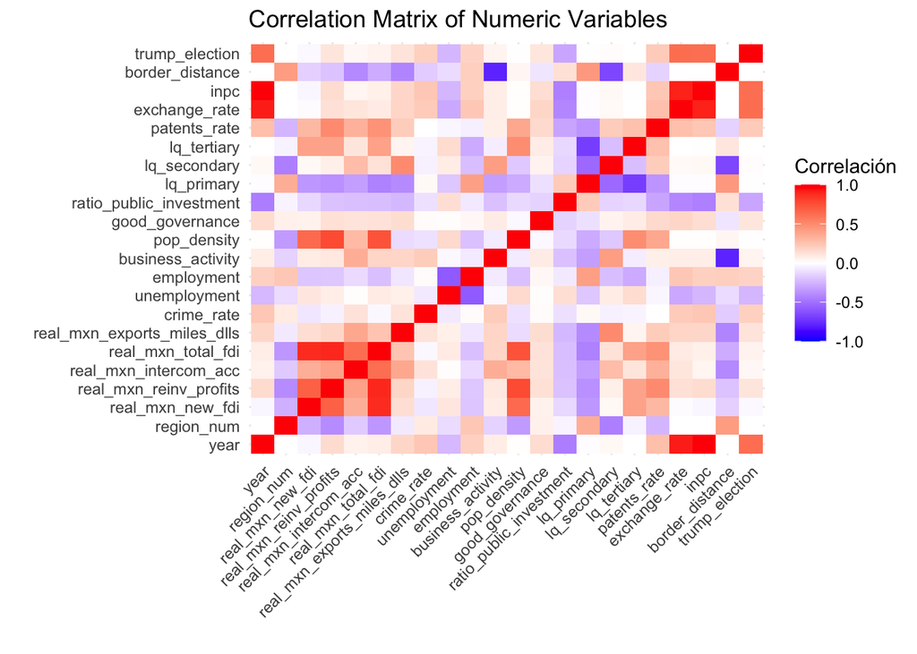

```r
nearshoring_numeric <- nearshoring_clean[, !names(nearshoring_clean) %in% c("real_wage", "total_fdi","intercom_acc","reinv_profits","new_fdi","total_fdi", "mxn_total_fdi","mxn_intercom_acc","mxn_reinv_profit","mxn_new_fdi")]

nearshoring_numeric <- nearshoring_numeric[, sapply(nearshoring_numeric, is.numeric)]

cor_matrix <- cor(nearshoring_numeric, use = "complete.obs")

cor_long <- melt(cor_matrix)


ggplot(cor_long, aes(Var1, Var2, fill = value)) +
  geom_tile() +
  scale_fill_gradient2(low = "blue", high = "red", mid = "white",
                       midpoint = 0, limit = c(-1,1), space = "Lab",
                       name="Correlación") +
  theme_minimal() +
  theme(axis.text.x = element_text(angle = 45, vjust = 1, hjust=1)) +
  labs(title = "Correlation Matrix of Numeric Variables", x = "", y ="")
```

## Analisis Exploratorio

### Estadísticos Descriptivos y de Dispersión

#### Estadísticas Generales

Estadísticas descriptivas por variable

|  | media | mínimo | Q1 | mediana | Q3 | máximo | std |
| --- | --- | --- | --- | --- | --- | --- | --- |
| pop_density | 299.46 | 7.74 | 39.56 | 61.77 | 150.45 | 6,211.45 | 1,047.59 |
| employment | 0.96 | 0.89 | 0.95 | 0.97 | 0.98 | 0.99 | 0.02 |
| crime_rate | 22.16 | 1.71 | 8.11 | 13.88 | 26.31 | 181.51 | 22.53 |
| business_activity | -1.76 | -2.98 | -2.26 | -2.07 | -1.77 | 2.47 | 0.95 |
| border_distance | 704.92 | 8.83 | 613.26 | 751.64 | 875.76 | 1,252.66 | 273.98 |
| lq_primary | 1.09 | 0.02 | 0.46 | 0.89 | 1.52 | 3.36 | 0.72 |
| lq_secondary | 0.99 | 0.51 | 0.76 | 0.99 | 1.21 | 1.63 | 0.26 |
| lq_tertiary | 0.98 | 0.72 | 0.89 | 0.98 | 1.05 | 1.36 | 0.13 |

#### Nueva Inversión Extranjera

##### Comportamiento por Region

Comportamiento de la **Nueva Inversión Extranjera** por región

| region_name | media | mínimo | Q1 | mediana | Q3 | máximo | std |
| --- | --- | --- | --- | --- | --- | --- | --- |
| Bajio | 6,354.53 | -5,648.14 | 1,750.30 | 5,617.62 | 9,178.96 | 28,064.26 | 5,986.31 |
| Centro | 12,384.38 | -15,304.55 | 933.89 | 3,453.24 | 15,417.95 | 114,415.82 | 20,982.14 |
| Norte | 8,574.35 | -7,785.59 | 3,638.47 | 6,700.87 | 10,453.62 | 69,642.78 | 9,422.06 |
| Occidente | 4,597.61 | -902.41 | 1,042.11 | 2,340.94 | 6,171.21 | 27,153.52 | 5,719.34 |
| Sur | 3,140.72 | -1,414.26 | 771.33 | 1,553.34 | 4,464.20 | 22,584.32 | 3,904.24 |

##### Comportamiento por Entidad

Comportamiento de la **Nueva Inversión Extranjera** por Entidad

| region_name | state | media | mínimo | Q1 | mediana | Q3 | máximo | std |
| --- | --- | --- | --- | --- | --- | --- | --- | --- |
| Bajio | Aguascalientes | 3,053.08 | 64.79 | 690.61 | 1,270.15 | 5,351.44 | 9,855.11 | 3,219.20 |
| Bajio | Guanajuato | 10,477.01 | 2,636.78 | 7,213.73 | 9,270.15 | 12,268.91 | 27,082.14 | 5,930.87 |
| Bajio | Queretaro | 5,990.70 | -5,648.14 | 4,354.16 | 6,504.73 | 7,169.48 | 11,970.58 | 4,047.50 |
| Bajio | San Luis Potosi | 6,839.50 | 519.09 | 2,688.05 | 5,617.62 | 9,265.20 | 21,777.33 | 5,737.25 |
| Bajio | Zacatecas | 5,412.38 | 250.09 | 594.33 | 2,353.44 | 6,205.66 | 28,064.26 | 7,894.95 |
| Centro | Ciudad de Mexico | 47,373.13 | -15,304.55 | 31,485.77 | 45,740.70 | 58,174.58 | 114,415.82 | 29,460.77 |
| Centro | Hidalgo | 1,329.82 | -4,400.93 | 431.00 | 1,049.46 | 2,450.85 | 4,816.77 | 2,021.54 |
| Centro | Mexico | 18,301.99 | 4,933.67 | 13,431.43 | 15,818.50 | 19,881.22 | 46,726.05 | 10,162.87 |
| Centro | Morelos | 1,338.80 | -1,129.81 | 243.86 | 729.52 | 1,542.86 | 5,054.33 | 1,700.71 |
| Centro | Puebla | 4,981.16 | 1,023.31 | 3,122.38 | 4,667.11 | 6,830.58 | 9,804.75 | 2,489.69 |
| Centro | Tlaxcala | 981.40 | -557.50 | 176.27 | 1,144.27 | 1,290.09 | 3,495.61 | 943.58 |
| Norte | Baja California | 7,816.23 | 387.60 | 3,828.79 | 7,399.52 | 9,907.95 | 20,410.32 | 4,972.75 |
| Norte | Chihuahua | 6,441.39 | -1,018.00 | 3,300.72 | 7,154.47 | 8,639.51 | 16,165.41 | 4,680.24 |
| Norte | Coahuila | 8,797.16 | 1,829.79 | 4,327.70 | 6,518.93 | 10,362.99 | 19,650.29 | 5,914.17 |
| Norte | Nuevo Leon | 18,316.85 | -215.80 | 10,467.48 | 14,141.52 | 20,409.05 | 69,642.78 | 17,432.54 |
| Norte | Sonora | 3,580.07 | -7,785.59 | 830.09 | 3,680.66 | 5,977.20 | 11,010.63 | 4,408.69 |
| Norte | Tamaulipas | 6,494.40 | -4,003.19 | 3,991.99 | 5,676.17 | 8,936.91 | 14,071.36 | 4,243.69 |

#### Actividad de Negocios

##### Comportamiento por Región

Comportamiento de la **Actividad de Negocio** por región

| region_name | media | mínimo | Q1 | mediana | Q3 | máximo | std |
| --- | --- | --- | --- | --- | --- | --- | --- |
| Bajio | -1.85 | -2.29 | -2.06 | -1.92 | -1.82 | 0.01 | 0.49 |
| Centro | -1.99 | -2.33 | -2.19 | -2.09 | -2.03 | 0.02 | 0.51 |
| Norte | -0.54 | -1.61 | -1.29 | -1.04 | -0.80 | 2.47 | 1.29 |
| Occidente | -2.07 | -2.57 | -2.29 | -2.18 | -2.08 | 0.01 | 0.54 |
| Sur | -2.17 | -2.98 | -2.41 | -2.29 | -2.07 | 0.01 | 0.60 |

##### Comportamiento por Entidad

Comportamiento de la **Actividad de Negocio** por Entidad

| region_name | state | media | mínimo | Q1 | mediana | Q3 | máximo | std |
| --- | --- | --- | --- | --- | --- | --- | --- | --- |
| Bajio | Aguascalientes | -1.93 | -2.29 | -2.22 | -1.98 | -1.88 | -0.00 | 0.53 |
| Bajio | Guanajuato | -1.92 | -2.25 | -2.17 | -1.98 | -1.89 | 0.01 | 0.52 |
| Bajio | Queretaro | -1.90 | -2.25 | -2.10 | -1.97 | -1.92 | 0.01 | 0.51 |
| Bajio | San Luis Potosi | -1.73 | -2.05 | -1.97 | -1.82 | -1.68 | 0.01 | 0.47 |
| Bajio | Zacatecas | -1.76 | -2.10 | -1.91 | -1.81 | -1.78 | -0.00 | 0.47 |
| Centro | Ciudad de Mexico | -1.96 | -2.19 | -2.14 | -2.08 | -2.01 | 0.01 | 0.51 |
| Centro | Hidalgo | -1.86 | -2.08 | -2.02 | -1.97 | -1.92 | 0.02 | 0.49 |
| Centro | Mexico | -2.05 | -2.33 | -2.26 | -2.17 | -2.06 | 0.00 | 0.54 |
| Centro | Morelos | -2.03 | -2.28 | -2.21 | -2.13 | -2.09 | 0.00 | 0.53 |
| Centro | Puebla | -2.04 | -2.32 | -2.25 | -2.14 | -2.09 | 0.01 | 0.54 |
| Centro | Tlaxcala | -1.99 | -2.25 | -2.16 | -2.11 | -2.02 | 0.00 | 0.52 |
| Norte | Baja California | 2.20 | 0.41 | 2.21 | 2.31 | 2.42 | 2.47 | 0.47 |
| Norte | Chihuahua | -1.30 | -1.55 | -1.47 | -1.36 | -1.26 | 0.01 | 0.36 |
| Norte | Coahuila | -1.33 | -1.61 | -1.45 | -1.38 | -1.33 | 0.02 | 0.36 |
| Norte | Nuevo Leon | -0.84 | -1.05 | -0.98 | -0.88 | -0.79 | 0.02 | 0.24 |
| Norte | Sonora | -0.97 | -1.22 | -1.16 | -0.99 | -0.92 | 0.01 | 0.28 |
| Norte | Tamaulipas | -1.00 | -1.14 | -1.11 | -1.07 | -1.02 | 0.01 | 0.26 |

- Tanto la mediana como la media **tienden a ubicarse en valores negativos**. Esto indica que, en la mayoría de los estados, la **Actividad de negocio** está por debajo de un punto de referencia, representando un **entorno empresarial menos dinámico**.
- Existe una dispersión considerable a nivel nacional, esto se debe a la dispersión que existe **principalmente en la región Norte** donde se encuentra y por diferencia el estado que **ha mantenido una Actividad de negocio alta a lo largo de los años**, Baja California.

## Visualización de los Datos

### Análisis Univariado

##### Histograma para Variables Numericas

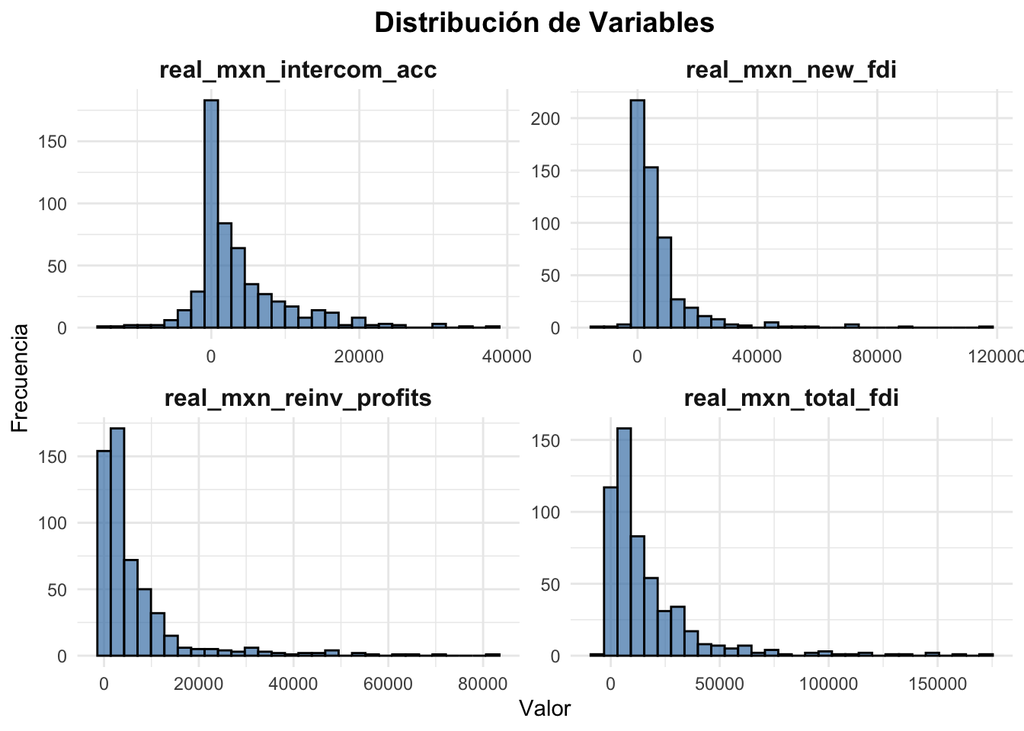

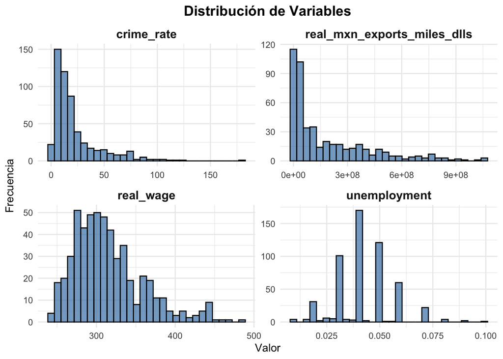

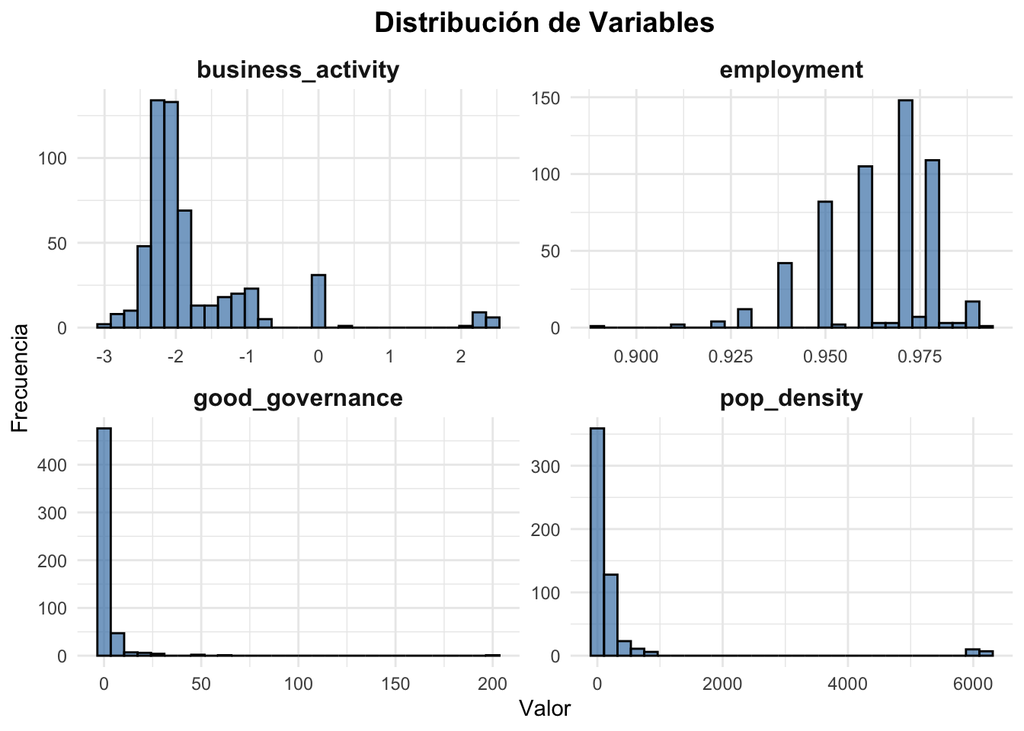

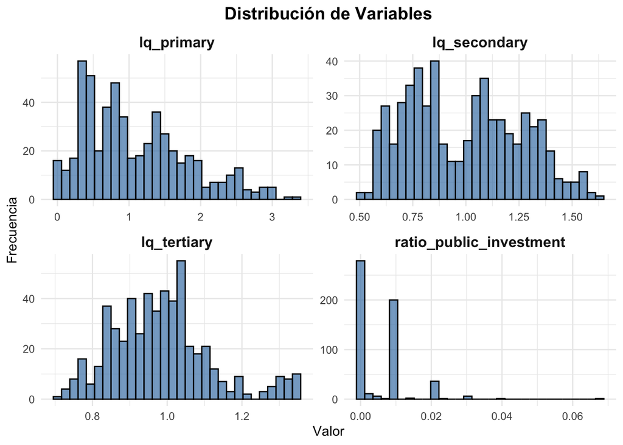

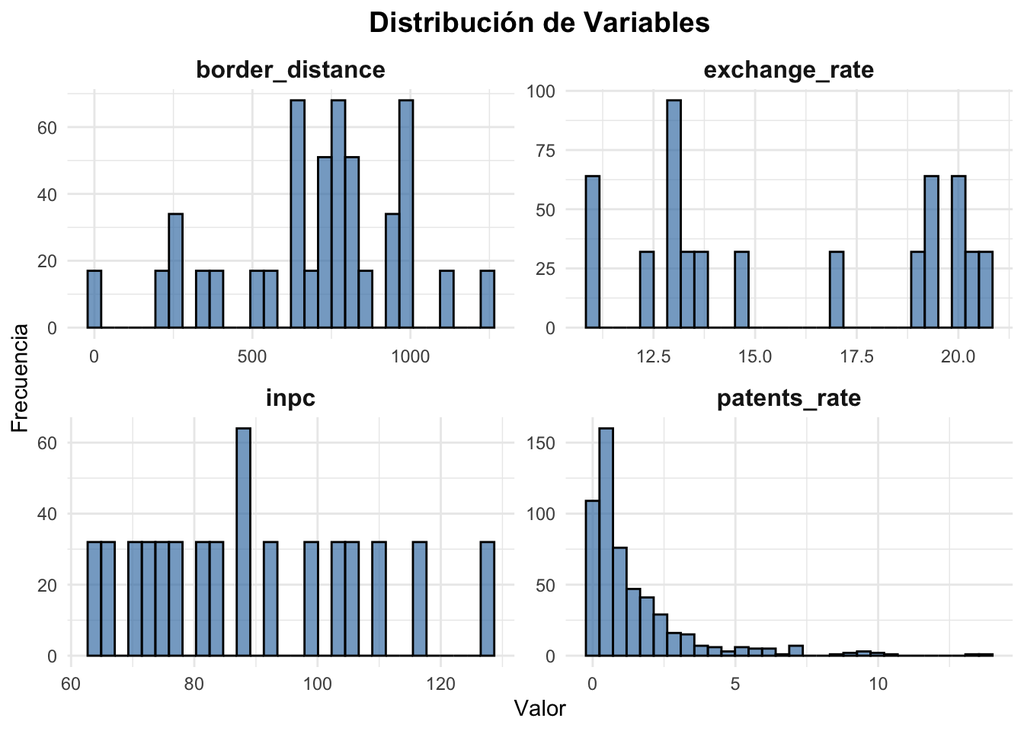

```r
# Filtrar solo las columnas numéricas y eliminar 'year' y 'trump_election'
nearshoring_numeric <- nearshoring_clean %>%
  select(where(is.numeric)) %>%
  select(-year, -trump_election, -region_num)

# Convertir a formato largo
nearshoring_numeric_long <- nearshoring_numeric %>%
  pivot_longer(cols = everything(), names_to = "Variable", values_to = "Valor")

# Obtener lista de variables en grupos de 4
variables <- unique(nearshoring_numeric_long$Variable)
num_groups <- ceiling(length(variables) / 4)  # Número de grupos de 4

# Generar histogramas en grupos de 4
for (i in seq(1, length(variables), by = 4)) {
  vars_subset <- variables[i:min(i+3, length(variables))]  # Seleccionar grupo de 4 variables

  plot <- ggplot(nearshoring_numeric_long %>% filter(Variable %in% vars_subset), aes(x = Valor)) +
    geom_histogram(bins = 30, fill = "steelblue", color = "black", alpha = 0.7) +
    facet_wrap(~Variable, scales = "free", ncol = 2) +  # Agrupar en 2 columnas
    theme_minimal() +
    labs(title = paste("Distribución de Variables"),
         x = "Valor",
         y = "Frecuencia") +
    theme(strip.text = element_text(face = "bold", size = 12),
          plot.title = element_text(hjust = 0.5, face = "bold", size = 14))

  print(plot)  # Mostrar gráfico
}
```

- La mayoría de las variables presentan **sesgo a la derecha**, indicando que hay pocos valores extremadamente altos y muchos valores bajos, lo que sugiere la necesidad de **transformaciones como exponente o logaritmo** para mejorar la linealidad en los modelos.
- Los coeficientes de localización sectorial (*LQ primary, LQ secondary, LQ tertiary*) tienen distribuciones más cercanas a normales, aunque *LQ secondary* presenta **bimodalidad**, lo que podría reflejar la presencia de dos tipos de regiones con dinámicas industriales diferentes.
- Algunas variables, como *patents_rate*, muestran **distribuciones con múltiples picos o poca variabilidad**, lo que puede afectar su capacidad predictiva en modelos de regresión si no se maneja adecuadamente.

##### Variables Numericas contra Nueva Inversión

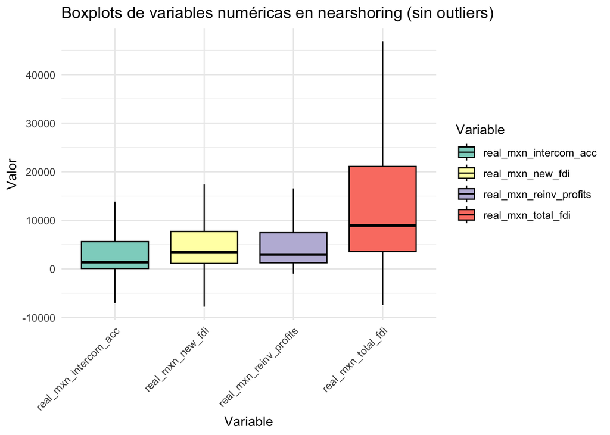

```r
# Quitamos exports porque sus datos opacan los de más gráficos
nearshoring2 <- nearshoring_clean %>%
  select(-real_mxn_exports_miles_dlls) %>%
  select(where(is.numeric)) %>%
  select(matches("real_mxn"))

# Transformar los datos a formato largo para ggplot
nearshoring_largo <- nearshoring2 %>%
  pivot_longer(cols = everything(), names_to = "Variable", values_to = "Valor")

# Crear boxplots sin outliers con diferentes colores por variable
ggplot(nearshoring_largo, aes(x = Variable, y = Valor, fill = Variable)) +
  geom_boxplot(outliers = FALSE,color = "black") +
  theme_minimal() +
  theme(axis.text.x = element_text(angle = 45, hjust = 1)) +
  labs(title = "Boxplots de variables numéricas en nearshoring (sin outliers)",
       x = "Variable",
       y = "Valor") +
  scale_fill_brewer(palette = "Set3")
```

##### Salarios por Region contra Nueva Inversión

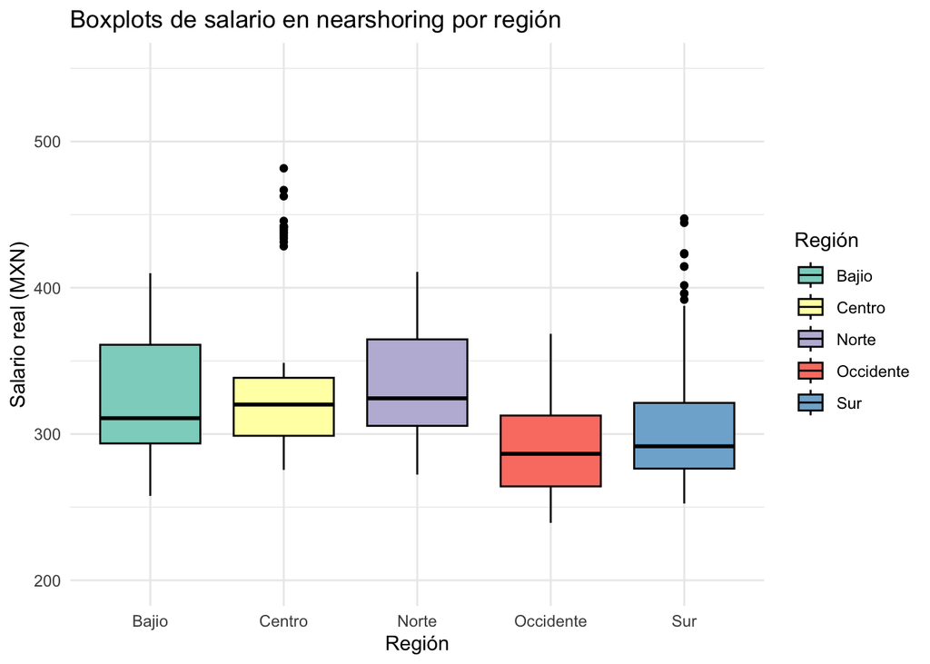

```r
# Crear boxplots con colores por región
ggplot(nearshoring_clean, aes(x = region_name, y = real_wage, fill = region_name)) +
  geom_boxplot(color = "black") +
  theme_minimal() +
  labs(title = "Boxplots de salario en nearshoring por región",
       x = "Región",
       y = "Salario real (MXN)",
       fill = "Región") +
  ylim(200, 550) +
  scale_fill_brewer(palette = "Set3")  # Paleta de colores para diferenciar regiones
```

Estos patrones pueden ser clave para diseñar estrategias de inversión diferenciadas según la región.

##### Tipos de Inversión Extranjera por Entidad

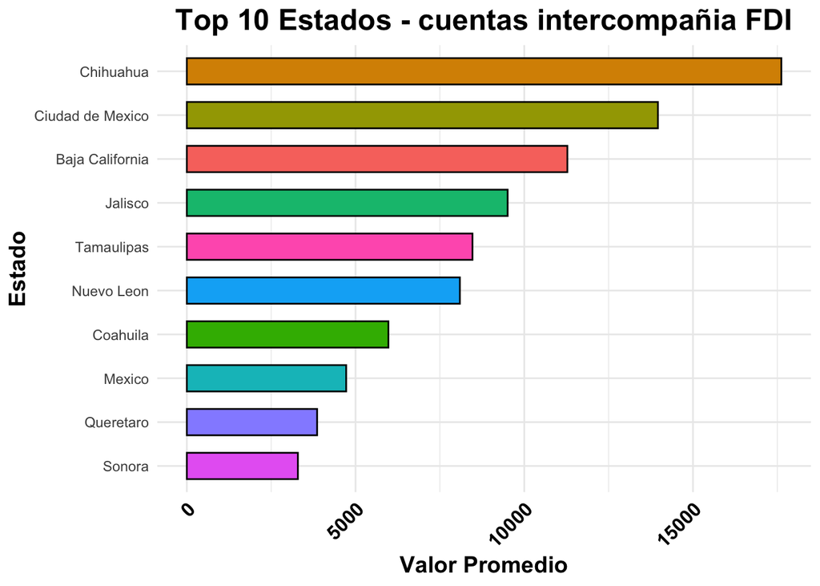

```r
# Lista de variables a analizar
variables_real_mxn <- c("real_mxn_intercom_acc", "real_mxn_new_fdi", "real_mxn_reinv_profits", "real_mxn_total_fdi")

nearshoring3 <- nearshoring %>%
  rename(
    "cuentas intercompañia FDI" = real_mxn_intercom_acc,
    "Nueva inversion extranjera directa" = real_mxn_new_fdi,
    "reinversión de las ganancias" = real_mxn_reinv_profits,
    "Inversion extranjera directa total" = real_mxn_total_fdi
  )
# Función para generar barplot de los 10 estados con valores más altos
crear_barplot <- function(var_name) {
  # Agrupar por estado y calcular el promedio de la variable
  datos_top <- nearshoring3 %>%
    group_by(state) %>%
    summarise(Valor_Promedio = mean(.data[[var_name]], na.rm = TRUE)) %>%
    top_n(10, Valor_Promedio) %>%
    arrange(desc(Valor_Promedio)) %>%
    mutate(state_id = as.factor(state))  # Convertir en factor para evitar error

  # Crear el barplot
  ggplot(datos_top, aes(x = reorder(state, Valor_Promedio), y = Valor_Promedio, fill = state_id)) +
    geom_bar(stat = "identity", color = "black", width = 0.6) +
    theme_minimal() +
    theme(
      axis.text.x = element_text(angle = 45, hjust = 1, size = 12, face = "bold", color = "black"),
      axis.title = element_text(size = 14, face = "bold"),
      plot.title = element_text(size = 18, face = "bold", hjust = 0.5),
      legend.position = "none"
    ) +
    labs(title = paste("Top 10 Estados -", var_name),
         x = "Estado",
         y = "Valor Promedio") +
    coord_flip()
}

# Generar los 4 gráficos
barplot_intercom_acc <- crear_barplot("cuentas intercompañia FDI")
barplot_new_fdi <- crear_barplot("Nueva inversion extranjera directa")
barplot_reinv_profits <- crear_barplot("reinversión de las ganancias")
barplot_total_fdi <- crear_barplot("Inversion extranjera directa total")

# Mostrar los gráficos individualmente
print(barplot_intercom_acc)
```

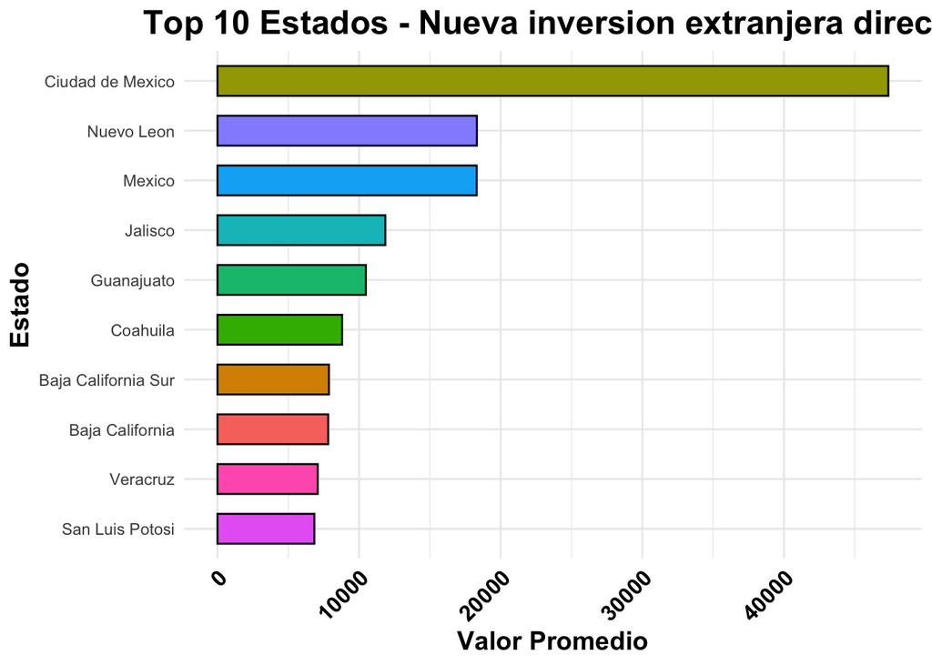

```r
print(barplot_new_fdi)
```

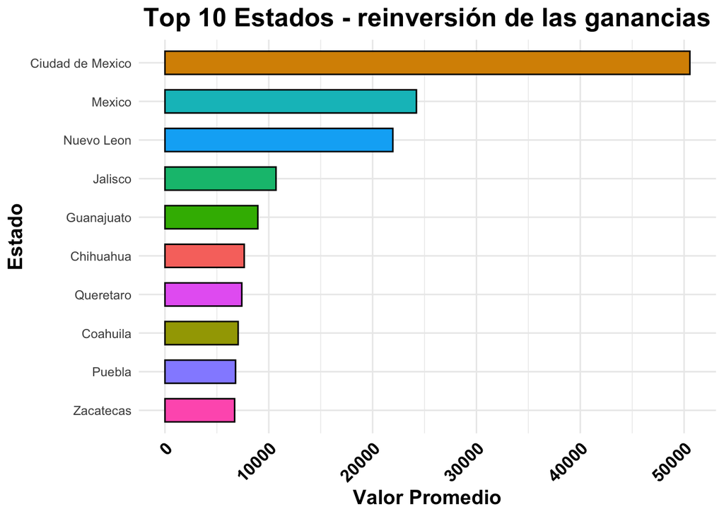

```r
print(barplot_reinv_profits)
```

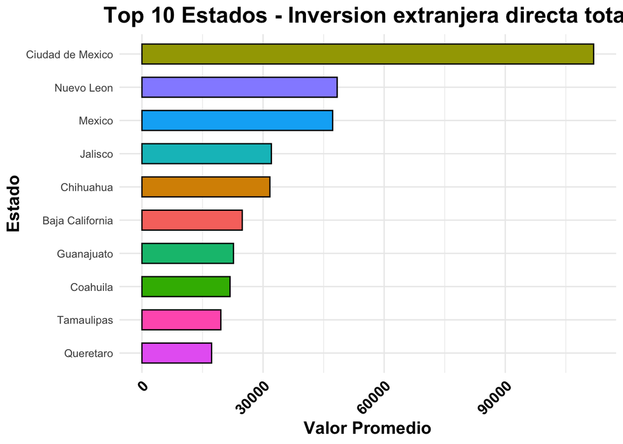

```r
print(barplot_total_fdi)
```

- **Chihuahua, Ciudad de México y Baja California** lideran en cuentas intercompañía de FDI, lo que sugiere que estas entidades tienen un fuerte ecosistema empresarial con múltiples filiales y conexiones globales.
- En términos de **nueva inversión extranjera directa**, **Ciudad de México es el principal receptor**, con un monto significativamente superior al de otros estados, lo que reafirma su papel como el centro económico y financiero más importante del país.
- **Nuevo León, Estado de México y Jalisco** también reciben altos niveles de nueva inversión extranjera, consolidándose como hubs industriales clave en el país.
- **La reinversión de ganancias sigue una tendencia similar**, con Ciudad de México nuevamente a la cabeza, lo que sugiere que las empresas ya establecidas en la capital están reinvirtiendo más capital en comparación con otros estados.
- **Nuevo León, Jalisco y Guanajuato** también presentan altos niveles de reinversión, lo que refleja la confianza de las empresas en estas entidades como destinos estratégicos para mantener operaciones.
- En la **Inversión Extranjera Directa Total**, Ciudad de México domina nuevamente el ranking, superando por un amplio margen a los demás estados, seguida por **Nuevo León, Estado de México y Jalisco**.
- **Chihuahua y Baja California** se destacan dentro de la región norte, lo que puede estar relacionado con su proximidad a la frontera con EE.UU. y su participación en la industria manufacturera.
- **Querétaro, Guanajuato y Coahuila** aparecen recurrentemente en las listas, consolidándose como estados clave en el nearshoring y en la atracción de inversiones en manufactura y tecnología.

Estos patrones reflejan cómo la inversión extranjera se concentra en ciertas entidades con ventajas estratégicas, como acceso a mercados globales, infraestructura industrial y estabilidad económica.

### Análisis Bivariado

##### Distribución Regional de la Inversión Extranjera Directa en México

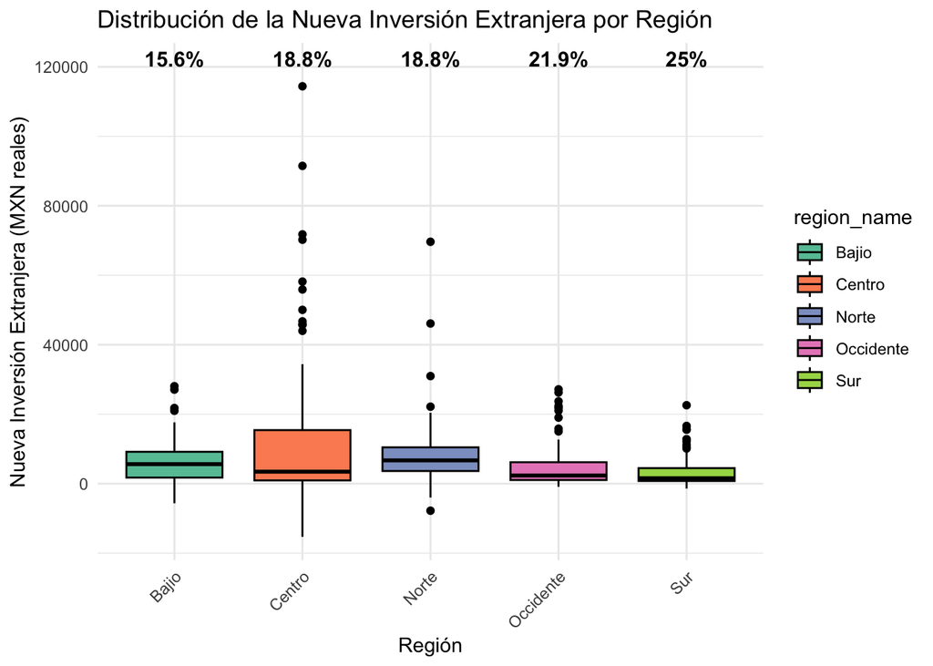

```r
# Calcular porcentaje de datos por región
nearshoring_summary <- nearshoring_clean %>%
  group_by(region_name) %>%
  summarise(count = n()) %>%
  mutate(percentage = (count / sum(count)) * 100)

# Crear el boxplot con etiquetas de porcentaje
ggplot(nearshoring_clean, aes(x = region_name, y = real_mxn_new_fdi, fill = region_name)) +
  geom_boxplot(color = "black") +  # Color de borde negro
  theme_minimal() +
  labs(title = "Distribución de la Nueva Inversión Extranjera por Región",
       x = "Región", y = "Nueva Inversión Extranjera (MXN reales)") +
  theme(axis.text.x = element_text(angle = 45, hjust = 1)) +
  scale_fill_brewer(palette = "Set2") +  # Paleta de colores más visualmente agradable
  geom_text(data = nearshoring_summary, aes(x = region_name, y = max(nearshoring_clean$real_mxn_new_fdi, na.rm = TRUE) * 1.05, label = paste0(round(percentage, 1), "%")), size = 4, fontface = "bold", vjust = 0, color = "black")  # Ajuste para que el texto esté arriba
```

##### Relación entre Inversión Extranjera y Densidad Poblacional

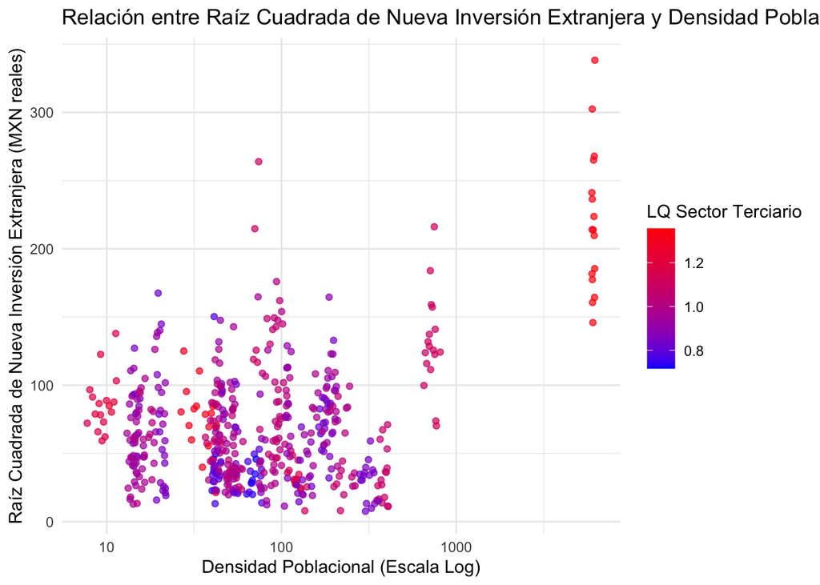

```r
# Scatter plot entre real_mxn_new_fdi y pop_density con color de puntos según valor de lq_tertiary
ggplot(nearshoring_clean, aes(x = pop_density, y = sqrt(real_mxn_new_fdi), color = lq_tertiary)) +
  geom_point(alpha = 0.7) +
  scale_x_log10() +  # Escala logarítmica para densidad poblacional
  scale_color_gradient(low = "blue", high = "red") +
  theme_minimal() +
  labs(title = "Relación entre Raíz Cuadrada de Nueva Inversión Extranjera y Densidad Poblacional",
       x = "Densidad Poblacional (Escala Log)",
       y = "Raíz Cuadrada de Nueva Inversión Extranjera (MXN reales)",
       color = "LQ Sector Terciario")
```

- **Las ciudades más densamente pobladas concentran mayores inversiones**, aunque la densidad por sí sola no parece ser un factor determinante.
- **El sector terciario juega un papel clave**: los estados con altos montos y alta densidad parecen tener altos niveles de especialización en servicios (LQ > 1.2) en común.
- **Las áreas con baja densidad y menor desarrollo en servicios tienen dificultades para atraer inversión**, sugiriendo que otros factores como infraestructura e incentivos fiscales pueden ser más relevantes.

##### Relación entre Inversión Extranjera y LQ del Sector Primario

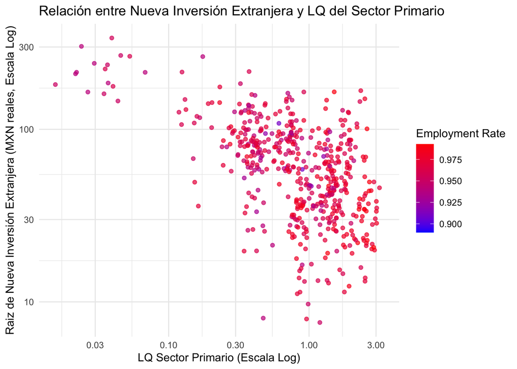

```r
ggplot(nearshoring_clean, aes(x = lq_primary, y = sqrt(real_mxn_new_fdi), color = employment)) +
  geom_point(alpha = 0.7) +
  scale_x_log10() +  # Escala logarítmica en el eje X
  scale_y_log10() +  # Escala logarítmica en el eje Y
  scale_color_gradient(low = "blue", high = "red") +  # Mapea el color según employment
  theme_minimal() +
  labs(title = "Relación entre Nueva Inversión Extranjera y LQ del Sector Primario",
       x = "LQ Sector Primario (Escala Log)",
       y = "Raiz de Nueva Inversión Extranjera (MXN reales, Escala Log)",
       color = "Employment Rate")
```

- **Las regiones con alta especialización en el sector primario (LQ > 1) tienden a recibir menos inversión extranjera**, lo que sugiere que este sector no es un motor clave para atraer capital externo.
- **Los valores más altos de inversión están concentrados en zonas con menor presencia del sector primario**, indicando que las inversiones se dirigen a economías más diversificadas o con mayor industrialización.
- **El empleo general es alto en casi todas las observaciones**, pero no parece estar relacionado con la inversión ni con la especialización en el sector primario, lo cual es congruente con el analisis de estadisticos descriptivo

##### Relación entre Inversión Extranjera y Tasa de Patentes

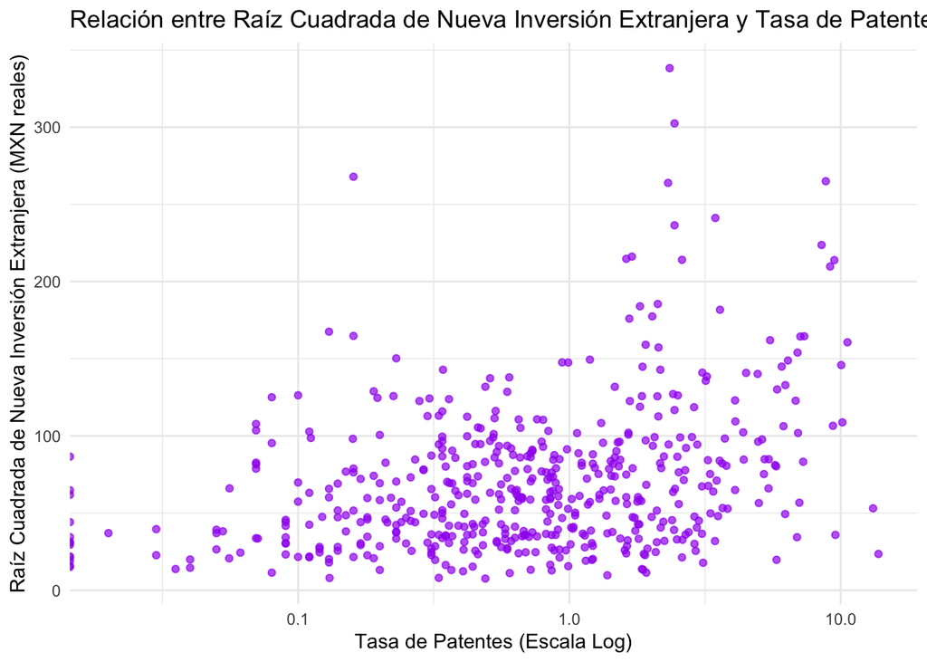

```r
# Scatter plot entre real_mxn_new_fdi y patents_rate
ggplot(nearshoring_clean, aes(x = patents_rate, y = sqrt(real_mxn_new_fdi))) +
  geom_point(alpha = 0.7, color = "purple") +
  #scale_y_log10() +
  scale_x_log10() + # Escala logarítmica en el eje X (tasa de patentes)
  theme_minimal() +
  labs(title = "Relación entre Raíz Cuadrada de Nueva Inversión Extranjera y Tasa de Patentes",
       x = "Tasa de Patentes (Escala Log)",
       y = "Raíz Cuadrada de Nueva Inversión Extranjera (MXN reales)")
```

- **No hay una relación lineal tan marcada entre la tasa de patentes y la inversión extranjera**, lo que sugiere que la innovación no es el principal factor para atraer capital.
- **Las inversiones altas se observan tanto en regiones con pocas como con muchas patentes**, aunque cabe mencionar que parecen ser más frecuentes en valores altos de tasa de patente.
- **Las regiones con mayor innovación pueden captar inversión, pero no de manera sistemática**, lo que sugiere que la investigación y el desarrollo deben ir acompañados de otras condiciones para atraer capital extranjero.

##### Intensidad de Inversión Extranjera por Estado Acumulada a través de los Años

```r
# Obtener el mapa de México con divisiones por estado
mexico_map <- ne_states(country = "Mexico", returnclass = "sf")

# Normalizar nombres: convertir a minúsculas, eliminar acentos, y renombrar Distrito Federal a Ciudad de Mexico
mexico_map$name <- mexico_map$name %>%
  tolower() %>%
  stri_trans_general("Latin-ASCII") %>%
  str_replace_all("distrito federal", "ciudad de mexico")  # Cambiar Distrito Federal a Ciudad de Mexico

# Asegurar que year sea numérico y calcular inversión acumulativa
nearshoring_clean_df <- nearshoring_clean %>%
  as.data.frame() %>%
  mutate(state = tolower(state) %>%
           stri_trans_general("Latin-ASCII") %>%
           str_replace_all("ciudad de mexico", "ciudad de mexico"),  # Asegurar consistencia en el nombre
         year = as.numeric(as.character(year))) %>%
  group_by(state, year) %>%
  summarise(real_mxn_new_fdi = sum(real_mxn_new_fdi, na.rm = TRUE), .groups = "drop") %>%
  arrange(state, year) %>%
  group_by(state) %>%
  mutate(cumulative_fdi = cumsum(real_mxn_new_fdi))  # Crear variable acumulativa

# Unir datos con el mapa
mexico_map <- mexico_map %>%
  left_join(nearshoring_clean_df, by = c("name" = "state"))

# Crear el mapa con animación acumulativa
animated_map <- ggplot(mexico_map) +
  geom_sf(aes(fill = cumulative_fdi), color = "black", size = 0.2) +
  scale_fill_gradient(low = "lightyellow", high = "red", na.value = "gray80") +
  theme_minimal() +
  labs(title = "Evolución Acumulativa de la Inversión Extranjera en México ({closest_state})",
       subtitle = "Valores en MXN reales (Acumulados por Año)",
       fill = "New FDI Acumulado",
       caption = "Fuente: Datos Nearshoring") +
  transition_states(year, transition_length = 2, state_length = 1, wrap = FALSE) +  # Mantiene valores acumulados
  ease_aes('linear')  # Transición lineal entre años

# Guardar el GIF con mayor calidad
# anim_save("mapa_inversion_mexico_acumulado.gif",
          # animated_map,
          # renderer = gifski_renderer(loop = TRUE, width = 1200, height = 800),  # Aumentar resolución
          # fps = 10,   # Aumentar cuadros por segundo para mayor fluidez
          # duration = 15)  # Extender la duración para una transición más suave
```

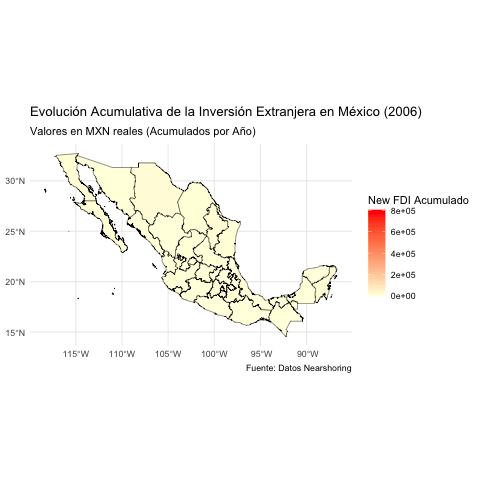

```r
# Insertar el GIF en R Markdown (solo en HTML)
knitr::include_graphics("mapa_inversion_mexico_acumulado.gif")
```

##### Inversión extranjera por región a través del tiempo

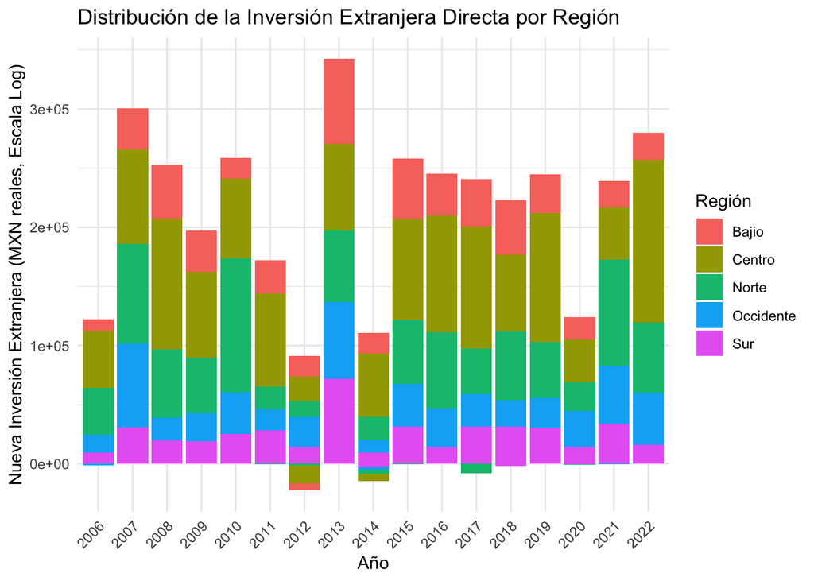

```r
# Asegurar que year sea numérico y region_name sea factor
nearshoring_clean_df <- nearshoring_clean %>%
  as.data.frame() %>%
  mutate(year = as.numeric(as.character(year)),
         region_name = as.factor(region_name))

# Graficar la inversión extranjera por región con barras apiladas
ggplot(nearshoring_clean_df, aes(x = factor(year), y = real_mxn_new_fdi, fill = region_name)) +
  geom_bar(stat = "identity", position = "stack") +  # Barras apiladas
  theme_minimal() +
  labs(title = "Distribución de la Inversión Extranjera Directa por Región",
       x = "Año",
       y = "Nueva Inversión Extranjera (MXN reales, Escala Log)",
       fill = "Región") +
  theme(axis.text.x = element_text(angle = 45, hjust = 1))
```

- **A diferencia del mapa acumulado, este gráfico muestra fluctuaciones anuales en la inversión**, destacando que los picos de inversión no siempre reflejan un crecimiento sostenido.
- **La inversión cayó drásticamente en 2020, posiblemente debido a la pandemia**, pero se recuperó rápidamente en 2021, aunque sin una tendencia clara de crecimiento a largo plazo.
- **No hay un incremento sistemático de nueva inversión con el tiempo**, lo que sugiere que la llegada de capital extranjero responde más a eventos específicos y condiciones económicas globales que a un crecimiento estructural del país.

## Hallazgos

#### 2. **Regiones con Baja Atracción de Inversión**

- **Sur y occidente (Oaxaca, Guerrero, Nayarit, Sinaloa)** presentan inversiones persistentemente bajas.
- **Posibles razones:** menor desarrollo industrial, infraestructura limitada, y menor integración en cadenas de suministro globales.

#### 3. **Crecimiento Acelerado en el Centro-Norte Después de 2020**

- **Estados como Zacatecas y San Luis Potosí han incrementado su inversión reciente**, probablemente debido a incentivos económicos y la reconfiguración de cadenas de suministro hacia EE.UU.
- Indicio de **nuevas oportunidades de nearshoring** fuera de los hubs tradicionales.

#### 4. **Impacto de la Pandemia en la Inversión**

- **Caída drástica en 2020**, seguida de una **rápida recuperación en 2021**.
- No se observa una tendencia clara de crecimiento sostenido, lo que sugiere que la inversión responde a **eventos externos más que a una expansión estructural**.

#### 5. **Transformaciones Clave para el Modelado**

- Aplicar la **raíz cuadrada de “New FDI”** mejoró la representación de la variable respuesta, reduciendo la influencia de outliers y permitiendo **mejores relaciones lineales**.
- Variables como **densidad poblacional y tasa de patentes** se interpretaron mejor en **escala logarítmica**.

#### 6. **Sector Económico y Atracción de Inversión**

- **Estados con alta presencia del sector terciario y manufacturero captan más inversión**, mientras que aquellos especializados en el sector primario tienen menor atracción.
- Implicación: **La diversificación económica es clave para la competitividad en inversión extranjera**.

#### 7. **Proximidad a EE.UU. como Factor Clave**

- **Estados fronterizos como Baja California y Chihuahua** han mantenido una inversión constante a lo largo del tiempo.
- La **cercanía geográfica sigue siendo un factor determinante** en la atracción de capital extranjero.

#### 8. **Innovación y su Relación con la Inversión**

- **No hay una relación clara entre la tasa de patentes y la inversión extranjera**.
- Indica que la **innovación por sí sola no es suficiente** para atraer capital sin otros incentivos como infraestructura y políticas fiscales.

#### 9. **Fluctuaciones en la Inversión Anual**

- La inversión no sigue un **patrón de crecimiento sostenido**, sino que varía por eventos específicos.
- Refuerza la idea de que **la inversión extranjera en México es altamente dependiente de factores coyunturales** como tratados comerciales o crisis económicas.

#### 10. **Diferencias en la Distribución Regional de Inversión**

- **Regiones con mayor volumen de datos (Sur y Occidente) tienen inversiones bajas y comprimidas**.
- **Centro y Norte tienen inversiones más dispersas y de mayor magnitud**, destacando como los destinos más atractivos para el capital extranjero.

Estos hallazgos proporcionan una base sólida para ajustar modelos predictivos y entender los determinantes clave de la inversión extranjera en México.

## Hipótesis Generales

1. **Las regiones con menor desarrollo industrial y diversificación económica atraen menos inversión extranjera.**
   - Estados como **Oaxaca, Guerrero, Nayarit y Sinaloa** muestran consistentemente bajos niveles de inversión, lo que sugiere que la falta de infraestructura y la dependencia de sectores primarios limitan su competitividad en el nearshoring.
2. **La proximidad a EE.UU. y la integración en cadenas de suministro globales favorecen la atracción de inversión.**
   - Estados en el **norte y bajío**, como **Nuevo León, Chihuahua y Guanajuato**, presentan mayor captación de capital extranjero, lo que indica que la cercanía a los mercados de destino y la presencia de clústeres industriales juegan un papel clave en las decisiones de inversión.
3. **La inversión en nearshoring se correlaciona con la infraestructura logística y conectividad.**
   - Estados con **mejor acceso a puertos, carreteras y redes ferroviarias** reciben mayores flujos de inversión, lo que sugiere que la eficiencia en logística es un factor determinante en la reubicación de operaciones extranjeras.

## Referencias

**Deloitte. (2020).** Global Supply Chain and Network Transformation: A Strategy for the Future. Deloitte Insights.

**McKinsey & Company. (2022).** Nearshoring: A Solution for U.S. Supply Chain Vulnerabilities. McKinsey Insights.

**The Economist. (2022).** The Rise of Nearshoring in Mexico.

**Moss, T. (2020).** Measuring the Impact of Nearshoring on Mexico’s Economy. Economía Mexicana, 29(2), 15-31.

**Wooldrige, J. M. (2010).** Econometric Analysis of Cross Section and Panel Data. MIT Press.